# Applied statistics in R

# L5: more about tidyverse

## Slices of data: slice()

```r
data |> slice(positions)
```

```r
starwars |> slice(positions)
```

Sometimes we may be interested in performing a **non-random discretionary sampling**, or in other words, **filter by position**: with `slice(positions)` we can select specific rows by passing as argument a **index vector**.

```r
# fila 1
starwars |>
  slice(1)
```

```
# A tibble: 1 × 4
  name           height  mass hair_color
  <chr>           <int> <dbl> <chr>
1 Luke Skywalker    172    77 blond
```

```r
# from the 7th to the 9th row
starwars |>
  slice(7:9)
```

```
# A tibble: 3 × 4
  name               height  mass hair_color
  <chr>               <int> <dbl> <chr>
1 Beru Whitesun Lars    165    75 brown
2 R5-D4                  97    32 <NA>
3 Biggs Darklighter     183    84 black
```

```r
# 2, 7, 10 and 31th rows
starwars |>
  slice(c(2, 7, 10, 31))
```

```
# A tibble: 4 × 8
  name             height  mass hair_color skin_color eye_color birth_year sex
  <chr>             <int> <dbl> <chr>      <chr>      <chr>          <dbl> <chr>
1 C-3PO               167    75 <NA>       gold       yellow           112 none
2 Beru Whitesun L…    165    75 brown      light      blue              47 fema…
3 Obi-Wan Kenobi      182    77 auburn, w… fair       blue-gray         57 male
4 Qui-Gon Jinn        193    89 brown      fair       blue              92 male
```

## Slices of data: slice()

```r
data |>
  slice(positions)
```

```r
starwars |>
  slice(positions)
```

We have default options:

- with `slice_head(n = ...)` and `slice_tail(n = ...)` we can get the **header and tail** of the table

```r
starwars |> slice_head(n = 2)
```

```
# A tibble: 2 × 4
  name           height  mass hair_color
  <chr>           <int> <dbl> <chr>
1 Luke Skywalker    172    77 blond
2 C-3PO             167    75 <NA>
```

```r
starwars |> slice_tail(n = 2)
```

```
# A tibble: 2 × 4
  name           height  mass hair_color
  <chr>           <int> <dbl> <chr>
1 BB8                NA    NA none
2 Captain Phasma     NA    NA none
```

## Slices of data: slice()

```r
data |>
  slice(positions)
```

```r
starwars |>
  slice(positions)
```

We have default options:

- with `slice_max()` and `slice_min()` we get the **rows with smallest/largest value of a variable** (if tie, all unless `with_ties = FALSE`) which we indicate in `order_by = ...`.

```r
starwars |> slice_min(mass, n = 2)
```

```
# A tibble: 2 × 4
  name         height  mass hair_color
  <chr>         <int> <dbl> <chr>
1 Ratts Tyerel     79    15 none
2 Yoda             66    17 white
```

```r
starwars |> slice_max(height, n = 2)
```

```
# A tibble: 2 × 4
  name        height  mass hair_color
  <chr>        <int> <dbl> <chr>
1 Yarael Poof    264    NA none
2 Tarfful        234   136 brown
```

## Random sampling

```r
data |>
  slice_aleatorias(positions)
```

```r
starwars |>
  slice_sample(positions)
```

The so-called **simple random sampling** is based on **selecting individuals randomly**, so that each one has certain **probabilities** of being selected. With `slice_sample(n = ...)` we can randomly extract n (a priori equiprobable) records.

```r
starwars |> slice_sample(n = 2)
```

```
# A tibble: 2 × 14
  name      height  mass hair_color skin_color eye_color birth_year sex   gender
  <chr>      <int> <dbl> <chr>      <chr>      <chr>          <dbl> <chr> <chr>
1 Cliegg L…    183    NA brown      fair       blue              82 male  mascu…
2 Ackbar       180    83 none       brown mot… orange            41 male  mascu…
# ℹ 5 more variables: homeworld <chr>, species <chr>, films <list>,
#   vehicles <list>, starships <list>
```

**Important**

**“Random” does not imply equiprobable**: a normal die is just as random as a trick die. There are no things “more random” than others, they simply have different underlying probability laws.

## Random sampling

```r
data |>
  slice_random(positions)
```

```r
starwars |>
  slice_sample(positions)
```

We can also indicate the **proportion of data to sample** (instead of the number) and if we want it to be **with replacement (that can be repeated)**.

```r
# 5% of random rows with replacement
starwars |>
  slice_sample(prop = 0.05, replace = TRUE)
```

```
# A tibble: 4 × 14
  name      height  mass hair_color skin_color eye_color birth_year sex   gender
  <chr>      <int> <dbl> <chr>      <chr>      <chr>          <dbl> <chr> <chr>
1 Owen Lars    178 120   brown, gr… light      blue            52   male  mascu…
2 Rey           NA  NA   brown      light      hazel           NA   fema… femin…
3 Han Solo     180  80   brown      fair       brown           29   male  mascu…
4 Boba Fett    183  78.2 black      fair       brown           31.5 male  mascu…
# ℹ 5 more variables: homeworld <chr>, species <chr>, films <list>,
#   vehicles <list>, starships <list>
```

## Random sampling

```r
data |>
  slice_random(positions)
```

```r
starwars |>
  slice_sample(positions)
```

As we said, “random” is not the same as “equiprobable”, so we can pass a **probability vector**. For example, let’s force that it is very improbable to draw a row other than the first two rows

```r
starwars |>
  slice_sample(n = 2, weight_by = c(0.495, 0.495, rep(0.01/85, 85)))
```

```
# A tibble: 2 × 14
  name      height  mass hair_color skin_color eye_color birth_year sex   gender
  <chr>      <int> <dbl> <chr>      <chr>      <chr>          <dbl> <chr> <chr>
1 C-3PO        167    75 <NA>       gold       yellow           112 none  mascu…
2 Luke Sky…    172    77 blond      fair       blue              19 male  mascu…
# ℹ 5 more variables: homeworld <chr>, species <chr>, films <list>,
#   vehicles <list>, starships <list>
```

```r
starwars |>
  slice_sample(n = 2, weight_by = c(0.495, 0.495, rep(0.01/85, 85)))
```

```
# A tibble: 2 × 14
  name      height  mass hair_color skin_color eye_color birth_year sex   gender
  <chr>      <int> <dbl> <chr>      <chr>      <chr>          <dbl> <chr> <chr>
1 Luke Sky…    172    77 blond      fair       blue              19 male  mascu…
2 C-3PO        167    75 <NA>       gold       yellow           112 none  mascu…
# ℹ 5 more variables: homeworld <chr>, species <chr>, films <list>,
#   vehicles <list>, starships <list>
```

## sample()

The `slice_sample()` function is simply a `{tidyverse}` integration of the basic `R` function known as `sample()` that allows us to **sample elements**

For example, let’s **sample 10 rolls of a die**, telling it

- **support** of our random variable (allowed values in `x`)
- **sample size** (`size`)
- **replacement** (if `TRUE` then they can come out repeated, as in the case of the die).

```r
sample(x = 1:6, size = 10, replace = TRUE)
```

```
 [1] 5 4 5 6 6 6 6 3 4 6
```

## sample()

The previous option generates events of a random variable **equiprobable** but as before, we can assign a vector of probabilities or **mass function** to it with the argument `prob = ...`.

```r
sample(x = 1:6, size = 50, replace = TRUE,
       prob = c(0.5, 0.2, 0.1, 0.1, 0.05, 0.05))
```

```
 [1] 1 1 5 2 1 1 2 2 2 6 2 1 1 1 1 2 2 1 1 1 1 1 3 1 2 5 1 5 6 5 4 6 1 2 3 1 1 6
[39] 2 2 1 2 1 1 3 2 6 1 2 5
```

## sample()

**How would you make the following statement?**

Suppose that seasonal flu episodes have been studied in a city. Let $X_m$ and $X_p$ be random variables such that $X_m=1$ if the mother has flu, $X_m=0$ if the mother does not have flu, $X_p=1$ if the father has flu and $X_p=0$ if the father does not have flu. The theoretical model associated with this type of epidemics indicates that the joint distribution is given by $P(X_m = 1, X_p=1)=0.02$, $P(X_m = 1, X_p=0)=0.08$, $P(X_m = 1, X_p=0)=0. 1$ and $P(X_m = 0, X_p=0)=0.8$

**Generate a sample** of size $n = 1000$ (support `"10"`, `"01"`, `"00"` and `"11"`) by making use of `runif()` and by making use of `sample()`.

## Sort by rows: arrange()

```r
data |> sort(var1, var2, ...)
```

```r
starwars |> arrange(var1, var2, ...)
```

We can also **order by rows** according to some variable with `arrange()`.

```r
starwars |> arrange(mass)
```

```
# A tibble: 5 × 6
  name                  height  mass hair_color skin_color  eye_color
  <chr>                  <int> <dbl> <chr>      <chr>       <chr>
1 Ratts Tyerel              79    15 none       grey, blue  unknown
2 Yoda                      66    17 white      green       brown
3 Wicket Systri Warrick     88    20 brown      brown       brown
4 R2-D2                     96    32 <NA>       white, blue red
5 R5-D4                     97    32 <NA>       white, red  red
```

By **from lowest to highest** but we can **reverse the order** with `desc()`.

```r
starwars |> arrange(desc(height))
```

```
# A tibble: 5 × 3
  name         height  mass
  <chr>         <int> <dbl>
1 Yarael Poof     264    NA
2 Tarfful         234   136
3 Lama Su         229    88
4 Chewbacca       228   112
5 Roos Tarpals    224    82
```

```r
starwars |> arrange(mass, desc(height))
```

```
# A tibble: 5 × 3
  name                  height  mass
  <chr>                  <int> <dbl>
1 Ratts Tyerel              79    15
2 Yoda                      66    17
3 Wicket Systri Warrick     88    20
4 R5-D4                     97    32
5 R2-D2                     96    32
```

## Remove duplicates: distinct()

```r
data |> no_duplicates(var1, var2, ...)
```

```r
starwars |> distinct(var1, var2, ...)
```

Many times we will need to make sure that there are no duplicates in some variable (DNI) and we can **delete duplicate rows** with `distinct()`.

```r
starwars |> distinct(sex)
```

```
# A tibble: 5 × 1
  sex
  <chr>
1 male
2 none
3 female
4 hermaphroditic
5 <NA>
```

To keep all the columns of the table we will use `.keep_all = TRUE`.

```r
starwars |> distinct(sex, .keep_all = TRUE)
```

[output not shown]

## Including rows: bind_rows()

```r
tibble1 |> include_rows(tibble2)
```

```r
tibble1 |> bind_rows(tibble2)
```

Finally, we can **bind new rows** with `bind_rows()` with **new observations in table** (if columns do not match fill with absent)

```r
data <-
  tibble("name" = c("javi", "laura"), "age" = c(33, 50))
data
```

```
# A tibble: 2 × 2
  name    age
  <chr> <dbl>
1 javi     33
2 laura    50
```

```r
data |> bind_rows(tibble("name" = c("carlos", NA), "cp" = c(28045, 28019)))
```

```
# A tibble: 4 × 3
  name     age    cp
  <chr>  <dbl> <dbl>
1 javi      33    NA
2 laura     50    NA
3 carlos    NA 28045
4 <NA>      NA 28019
```

## 💻 It’s your turn

**Try to perform the following exercises without looking at the solutions**

- **Exercise 1**
- **Exercise 2**
- **Exercise 3**
- **Exercise 4**
- **Exercise 5**
- **Exercise 6**
- **Exercise 7**

```r
starwars |>
  filter(eye_color == "brown" & species == "Human") |>
  arrange(height, desc(mass))
```

📝 Randomly extracts 3 records.

```r
starwars |> slice_sample(n = 3)
```

📝 Extracts 10% of the records randomly.

```r
starwars |> slice_sample(prop = 0.1)
```

📝R andomly draws 10 characters but in such a way that the probability of each character being drawn is proportional to its weight (heavier, more likely).

```r
starwars |>
  drop_na(mass) |>
  slice_sample(n = 10, weight_by = mass)
```

📝 Select the 3 oldest characters.

```r
starwars |> slice_max(birth_year, n = 3)
```

📝 To find out what unique values are in the hair color, remove duplicates of the `hair_color` variable by first removing the missing ones from the `hair_color` variable.

```r
starwars |>
  drop_na(hair_color) |>
  distinct(hair_color)
```

📝 Of the characters that are human and taller than 160 cm, eliminate duplicates in eye color, eliminate absent in weight, select the 3 tallest, and order from tallest to shortest in weight. Return the table.

```r
starwars |>
  filter(species == "Human" & height > 160) |>
  distinct(eye_color, .keep_all = TRUE) |>
  drop_na(mass) |>
  slice_max(height, n = 3) |>
  arrange(desc(mass))
```

## Move columns: relocate()

```r
data |>
  move(var1, after = var2)
```

```r
starwars |>
  relocate(var1, .after = var2)
```

To facilitate the **relocation of variables** we have a function for it, `relocate()`, indicating in `.after` or `.before` **behind** or **in front** of which columns we want to move them.

```r
starwars |> relocate(species, .before = name)
```

```
# A tibble: 87 × 14
   species name    height  mass hair_color skin_color eye_color birth_year sex
   <chr>   <chr>    <int> <dbl> <chr>      <chr>      <chr>          <dbl> <chr>
 1 Human   Luke S…    172    77 blond      fair       blue            19   male
 2 Droid   C-3PO      167    75 <NA>       gold       yellow         112   none
 3 Droid   R2-D2       96    32 <NA>       white, bl… red             33   none
 4 Human   Darth …    202   136 none       white      yellow          41.9 male
 5 Human   Leia O…    150    49 brown      light      brown           19   fema…
 6 Human   Owen L…    178   120 brown, gr… light      blue            52   male
 7 Human   Beru W…    165    75 brown      light      blue            47   fema…
 8 Droid   R5-D4       97    32 <NA>       white, red red             NA   none
 9 Human   Biggs …    183    84 black      light      brown           24   male
10 Human   Obi-Wa…    182    77 auburn, w… fair       blue-gray       57   male
# ℹ 77 more rows
# ℹ 5 more variables: gender <chr>, homeworld <chr>, films <list>,
#   vehicles <list>, starships <list>
```

## Rename: rename()

```r
data |> rename(new = old)
```

```r
starwars |> rename(new = old)
```

Sometimes we may also want to **modify the “meta-information”** of the data, **renaming columns**. To do this we will use `rename()` by typing **first the new name** and then the **old**.

```r
starwars |> rename(nombre = name, altura = height, peso = mass)
```

```
# A tibble: 87 × 14
   nombre   altura  peso hair_color skin_color eye_color birth_year sex   gender
   <chr>     <int> <dbl> <chr>      <chr>      <chr>          <dbl> <chr> <chr>
 1 Luke Sk…    172    77 blond      fair       blue            19   male  mascu…
 2 C-3PO       167    75 <NA>       gold       yellow         112   none  mascu…
 3 R2-D2        96    32 <NA>       white, bl… red             33   none  mascu…
 4 Darth V…    202   136 none       white      yellow          41.9 male  mascu…
 5 Leia Or…    150    49 brown      light      brown           19   fema… femin…
 6 Owen La…    178   120 brown, gr… light      blue            52   male  mascu…
 7 Beru Wh…    165    75 brown      light      blue            47   fema… femin…
 8 R5-D4        97    32 <NA>       white, red red             NA   none  mascu…
 9 Biggs D…    183    84 black      light      brown           24   male  mascu…
10 Obi-Wan…    182    77 auburn, w… fair       blue-gray       57   male  mascu…
# ℹ 77 more rows
# ℹ 5 more variables: homeworld <chr>, species <chr>, films <list>,
#   vehicles <list>, starships <list>
```

## Extract columns: pull()

```r
data |> extract(var)
```

```r
starwars |> pull(var)
```

If you look at the output of the `select()` **still a tibble table**, it preserves the nature of our data.

```r
starwars |> select(name)
```

```
# A tibble: 87 × 1
   name
   <chr>
 1 Luke Skywalker
 2 C-3PO
 3 R2-D2
 4 Darth Vader
 5 Leia Organa
 6 Owen Lars
 7 Beru Whitesun Lars
 8 R5-D4
 9 Biggs Darklighter
10 Obi-Wan Kenobi
# ℹ 77 more rows
```

## Extract columns: pull()

```r
data |> extract(var)
```

```r
starwars |> pull(var)
```

Sometimes we will not want such a structure but **literally extract the column in a VECTOR**, something we can do with `pull()`.

```r
starwars |> pull(name)
```

```
 [1] "Luke Skywalker"        "C-3PO"                 "R2-D2"
 [4] "Darth Vader"           "Leia Organa"           "Owen Lars"
 [7] "Beru Whitesun Lars"    "R5-D4"                 "Biggs Darklighter"
[10] "Obi-Wan Kenobi"        "Anakin Skywalker"      "Wilhuff Tarkin"
[13] "Chewbacca"             "Han Solo"              "Greedo"
[16] "Jabba Desilijic Tiure" "Wedge Antilles"        "Jek Tono Porkins"
[19] "Yoda"                  "Palpatine"             "Boba Fett"
[22] "IG-88"                 "Bossk"                 "Lando Calrissian"
[25] "Lobot"                 "Ackbar"                "Mon Mothma"
[28] "Arvel Crynyd"          "Wicket Systri Warrick" "Nien Nunb"
[31] "Qui-Gon Jinn"          "Nute Gunray"           "Finis Valorum"
[34] "Padmé Amidala"         "Jar Jar Binks"         "Roos Tarpals"
[37] "Rugor Nass"            "Ric Olié"              "Watto"
[40] "Sebulba"               "Quarsh Panaka"         "Shmi Skywalker"
[43] "Darth Maul"            "Bib Fortuna"           "Ayla Secura"
[46] "Ratts Tyerel"          "Dud Bolt"              "Gasgano"
[49] "Ben Quadinaros"        "Mace Windu"            "Ki-Adi-Mundi"
[52] "Kit Fisto"             "Eeth Koth"             "Adi Gallia"
[55] "Saesee Tiin"           "Yarael Poof"           "Plo Koon"
[58] "Mas Amedda"            "Gregar Typho"          "Cordé"
[61] "Cliegg Lars"           "Poggle the Lesser"     "Luminara Unduli"
[64] "Barriss Offee"         "Dormé"                 "Dooku"
[67] "Bail Prestor Organa"   "Jango Fett"            "Zam Wesell"
[70] "Dexter Jettster"       "Lama Su"               "Taun We"
[73] "Jocasta Nu"            "R4-P17"                "Wat Tambor"
[76] "San Hill"              "Shaak Ti"              "Grievous"
[79] "Tarfful"               "Raymus Antilles"       "Sly Moore"
[82] "Tion Medon"            "Finn"                  "Rey"
[85] "Poe Dameron"           "BB8"                   "Captain Phasma"
```

## 💻 It’s your turn

**Try to perform the following exercises without looking at the solutions**

- **Exercise 1**
- **Exercise 2**
- **Exercise 3**
- **Exercise 4**
- **Exercise 5**
- **Exercise 6**

📝 Translate the names of the columns into Spanish.

```r
starwars |>
  rename(nombre = name, altura = height, color_pelo = hair_color,
         color_piel = skin_color, color_ojos = eye_color)
```

📝 Place the hair color variable just after the name variable.

```r
starwars_2 |>
  relocate(hair_color, .after = name)
```

📝 Check how many unique modalities there are in the hair color variable (without using `unique()`).

```r
starwars_2 |>
  distinct(hair_color)
```

📝 From the original data set, it removes the list type columns, and then removes duplicates in the `eye_color` variable. After removing duplicates it extracts that column into a vector.

```r
starwars |>
  select(-where(is.list)) |>
  distinct(eye_color, .keep_all = TRUE) |>
  pull(eye_color)
```

📝 From the original starwars dataset, with only the characters whose height is known, extract in a vector with that variable.

```r
starwars |>
  drop_na(height) |>
  pull(height)
```

📝 After obtaining the vector from the previous Exercise, use this vector to randomly sample 50% of the data so that the probability of each character being chosen is inversely proportional to their height (shorter, more options).

```r
heights <-
  starwars |>
  drop_na(height) |>
  pull(height)

starwars |>
  slice_sample(prop = 0.5, weight_by = 1/heights)
```

# L6: more about tidyverse

## Modify columns: mutate()

```r
data |> modify(new_var = funcion())
```

```r
starwars |> mutate(new_var = function())
```

In many occasions we will want to **modify or create variables** with `mutate()`.

Let’s create for example a new variable `height_m` with the height in meters.

```r
starwars |> mutate(height_m = height / 100)
```

```
# A tibble: 87 × 15
   name     height  mass hair_color skin_color eye_color birth_year sex   gender
   <chr>     <int> <dbl> <chr>      <chr>      <chr>          <dbl> <chr> <chr>
 1 Luke Sk…    172    77 blond      fair       blue            19   male  mascu…
 2 C-3PO       167    75 <NA>       gold       yellow         112   none  mascu…
 3 R2-D2        96    32 <NA>       white, bl… red             33   none  mascu…
 4 Darth V…    202   136 none       white      yellow          41.9 male  mascu…
 5 Leia Or…    150    49 brown      light      brown           19   fema… femin…
 6 Owen La…    178   120 brown, gr… light      blue            52   male  mascu…
 7 Beru Wh…    165    75 brown      light      blue            47   fema… femin…
 8 R5-D4        97    32 <NA>       white, red red             NA   none  mascu…
 9 Biggs D…    183    84 black      light      brown           24   male  mascu…
10 Obi-Wan…    182    77 auburn, w… fair       blue-gray       57   male  mascu…
# ℹ 77 more rows
# ℹ 6 more variables: homeworld <chr>, species <chr>, films <list>,
#   vehicles <list>, starships <list>, height_m <dbl>
```

## Modify columns: mutate()

```r
data |> modify(new_var = funcion())
```

```r
starwars |> mutate(new_var = function())
```

In addition with the optional arguments we can **reposition the modified column**

```r
starwars |>
  mutate(height_m = height / 100,
         BMI = mass / (height_m^2), .before = name)
```

```
# A tibble: 87 × 16
   height_m   BMI name   height  mass hair_color skin_color eye_color birth_year
      <dbl> <dbl> <chr>   <int> <dbl> <chr>      <chr>      <chr>          <dbl>
 1     1.72  26.0 Luke …    172    77 blond      fair       blue            19
 2     1.67  26.9 C-3PO     167    75 <NA>       gold       yellow         112
 3     0.96  34.7 R2-D2      96    32 <NA>       white, bl… red             33
 4     2.02  33.3 Darth…    202   136 none       white      yellow          41.9
 5     1.5   21.8 Leia …    150    49 brown      light      brown           19
 6     1.78  37.9 Owen …    178   120 brown, gr… light      blue            52
 7     1.65  27.5 Beru …    165    75 brown      light      blue            47
 8     0.97  34.0 R5-D4      97    32 <NA>       white, red red             NA
 9     1.83  25.1 Biggs…    183    84 black      light      brown           24
10     1.82  23.2 Obi-W…    182    77 auburn, w… fair       blue-gray       57
# ℹ 77 more rows
# ℹ 7 more variables: sex <chr>, gender <chr>, homeworld <chr>, species <chr>,
#   films <list>, vehicles <list>, starships <list>
```

## Modify columns: mutate()

```r
data |> modify(new_var = funcion())
```

```r
starwars |> mutate(new_var = function())
```

**Important**

When we apply `mutate()`, we must remember that the **operations are performed vector by vector**, element by element, so the function we use inside must return a vector of equal length. Otherwise, **it will return a constant**.

```r
starwars |>
  mutate(constante = mean(mass, na.rm = TRUE), .before = name)
```

```
# A tibble: 87 × 15
   constante name  height  mass hair_color skin_color eye_color birth_year sex
       <dbl> <chr>  <int> <dbl> <chr>      <chr>      <chr>          <dbl> <chr>
 1      97.3 Luke…    172    77 blond      fair       blue            19   male
 2      97.3 C-3PO    167    75 <NA>       gold       yellow         112   none
 3      97.3 R2-D2     96    32 <NA>       white, bl… red             33   none
 4      97.3 Dart…    202   136 none       white      yellow          41.9 male
 5      97.3 Leia…    150    49 brown      light      brown           19   fema…
 6      97.3 Owen…    178   120 brown, gr… light      blue            52   male
 7      97.3 Beru…    165    75 brown      light      blue            47   fema…
 8      97.3 R5-D4     97    32 <NA>       white, red red             NA   none
 9      97.3 Bigg…    183    84 black      light      brown           24   male
10      97.3 Obi-…    182    77 auburn, w… fair       blue-gray       57   male
# ℹ 77 more rows
# ℹ 6 more variables: gender <chr>, homeworld <chr>, species <chr>,
#   films <list>, vehicles <list>, starships <list>
```

## Recategorize: if_else()

We can also combine `mutate()` with the `if_else()` control expression to **recategorize the variable**: if **a condition** is met, it does one thing, otherwise another.

```r
starwars |>
  mutate(human = if_else(species == "Human", "Human", "Not Human"),
         .after = name) |>
  select(name:mass)
```

```
# A tibble: 87 × 4
   name               human     height  mass
   <chr>              <chr>      <int> <dbl>
 1 Luke Skywalker     Human        172    77
 2 C-3PO              Not Human    167    75
 3 R2-D2              Not Human     96    32
 4 Darth Vader        Human        202   136
 5 Leia Organa        Human        150    49
 6 Owen Lars          Human        178   120
 7 Beru Whitesun Lars Human        165    75
 8 R5-D4              Not Human     97    32
 9 Biggs Darklighter  Human        183    84
10 Obi-Wan Kenobi     Human        182    77
# ℹ 77 more rows
```

## Recategorize: case_when()

For **more complex categorizations** we have `case_when()`, for example, to create a category of characters based on their height.

```r
starwars |>
  drop_na(height) |>
  mutate(altura = case_when(height < 120 ~ "dwarf",
                            height < 160 ~ "short",
                            height < 180 ~ "normal",
                            height < 200 ~ "tall",
                            TRUE ~ "giant"), .before = name)
```

```
# A tibble: 81 × 15
   altura name     height  mass hair_color skin_color eye_color birth_year sex
   <chr>  <chr>     <int> <dbl> <chr>      <chr>      <chr>          <dbl> <chr>
 1 normal Luke Sk…    172    77 blond      fair       blue            19   male
 2 normal C-3PO       167    75 <NA>       gold       yellow         112   none
 3 dwarf  R2-D2        96    32 <NA>       white, bl… red             33   none
 4 giant  Darth V…    202   136 none       white      yellow          41.9 male
 5 short  Leia Or…    150    49 brown      light      brown           19   fema…
 6 normal Owen La…    178   120 brown, gr… light      blue            52   male
 7 normal Beru Wh…    165    75 brown      light      blue            47   fema…
 8 dwarf  R5-D4        97    32 <NA>       white, red red             NA   none
 9 tall   Biggs D…    183    84 black      light      brown           24   male
10 tall   Obi-Wan…    182    77 auburn, w… fair       blue-gray       57   male
# ℹ 71 more rows
# ℹ 6 more variables: gender <chr>, homeworld <chr>, species <chr>,
#   films <list>, vehicles <list>, starships <list>
```

## 💻 It’s your turn

**Try to perform the following exercises without looking at the solutions**

- **Exercise 1**
- **Exercise 2**
- **Exercise 3**
- **Exercise 4**
- **Exercise 5**
- **Exercise 6**
- **Exercise 7**

📝 Select only the variables name, height and as well as all those variables related to the color, while keeping only those that are not absent in the height.

```r
starwars |>
  select(name, height, contains("color")) |>
  drop_na(height)
```

📝 With the data obtained from the previous Exercise, translate the names of the columns into Spanish or your mother language.

```r
starwars |>
  select(name, height, contains("color")) |>
  drop_na(height) |>
  rename(nombre = name, altura = height,
         color_pelo = eye_color, color_piel = skin_color,
         color_pelo = hair_color)
```

📝 With the data obtained from the previous Exercise, place the hair color variable just after the name variable.

```r
starwars |>
  select(name, height, contains("color")) |>
  drop_na(height) |>
  rename(nombre = name, altura = height,
         color_pelo = eye_color, color_piel = skin_color,
         color_pelo = hair_color) |>
  relocate(color_pelo, .after = nombre)
```

📝 With the original data, check how many unique modalities there are in the hair color variable.

```r
starwars |>
  distinct(hair_color) |>
  nrow()
```

📝 From the original dataset, select only the numeric and text variables. Then define a new variable called `under_18` to recategorize the age variable: `TRUE` if under age and `FALSE` if not.

```r
starwars |>
  select(where(is.numeric) | where(is.character)) |>
  mutate(under_18 = birth_year < 18)
```

📝 From the original dataset, create a new column named `auburn` that tells us TRUE if the hair color contains that word and FALSE otherwise (reminder `str_detect()`).

```r
starwars |>
  mutate(auburn = str_detect(hair_color, "auburn"))
```

📝 From the original dataset, include a column that calculates BMI. After that, create a new variable that values `NA` if not human, `underweight` below 18, `normal` between 18 and 30, `overweight` above 30.

```r
starwars |>
  mutate(IMC = mass / ((height/100)^2),
         IMC_recat = case_when(species != "Human" ~ NA,
                               IMC < 18 ~ "underweight",
                               IMC < 30 ~ "normal",
                               TRUE ~ "overweight"),
         .after = name)
```

## 🐣 Case study I: Taylor Swift

We will analyse Taylor Swift songs from `{taylor}` package (you need to install it before)

```r
library(taylor)
taylor_album_songs
```

```
# A tibble: 240 × 29
   album_name   ep    album_release track_number track_name     artist featuring
   <chr>        <lgl> <date>               <int> <chr>          <chr>  <chr>
 1 Taylor Swift FALSE 2006-10-24               1 Tim McGraw     Taylo… <NA>
 2 Taylor Swift FALSE 2006-10-24               2 Picture To Bu… Taylo… <NA>
 3 Taylor Swift FALSE 2006-10-24               3 Teardrops On … Taylo… <NA>
 4 Taylor Swift FALSE 2006-10-24               4 A Place In Th… Taylo… <NA>
 5 Taylor Swift FALSE 2006-10-24               5 Cold As You    Taylo… <NA>
 6 Taylor Swift FALSE 2006-10-24               6 The Outside    Taylo… <NA>
 7 Taylor Swift FALSE 2006-10-24               7 Tied Together… Taylo… <NA>
 8 Taylor Swift FALSE 2006-10-24               8 Stay Beautiful Taylo… <NA>
 9 Taylor Swift FALSE 2006-10-24               9 Should've Sai… Taylo… <NA>
10 Taylor Swift FALSE 2006-10-24              10 Mary's Song (… Taylo… <NA>
# ℹ 230 more rows
# ℹ 22 more variables: bonus_track <lgl>, promotional_release <date>,
#   single_release <date>, track_release <date>, danceability <dbl>,
#   energy <dbl>, key <int>, loudness <dbl>, mode <int>, speechiness <dbl>,
#   acousticness <dbl>, instrumentalness <dbl>, liveness <dbl>, valence <dbl>,
#   tempo <dbl>, time_signature <int>, duration_ms <int>, explicit <lgl>,
#   key_name <chr>, mode_name <chr>, key_mode <chr>, lyrics <list>
```

Try to answer the questions posed in the **workbook `intro-tidyverse`**

## 🐣 Case study II: The Lord of the Rings

To practice some `{dplyr}` functions we are going to use data from the **Lord of the Rings trilogy** movies. We will load the data directly from the web (Github in this case), without going through the computer before, simply **indicating as path the web where the file is**

- The Fellowship of the Ring -> https://raw.githubusercontent.com/jennybc/lotr-tidy/master/data/The_Fellowship_Of_The_Ring.csv
- The 2 Towers -> https://raw.githubusercontent.com/jennybc/lotr-tidy/master/data/The_Two_Towers.csv
- The Return of the King -> https://raw.githubusercontent.com/jennybc/lotr-tidy/master/data/The_Return_Of_The_King.csv.

```r
library(readr)
lotr_1 <-
  read_csv(file = "https://raw.githubusercontent.com/jennybc/lotr-tidy/master/data/The_Fellowship_Of_The_Ring.csv")
lotr_2 <-
  read_csv(file = "https://raw.githubusercontent.com/jennybc/lotr-tidy/master/data/The_Two_Towers.csv")
lotr_3 <-
  read_csv(file = "https://raw.githubusercontent.com/jennybc/lotr-tidy/master/data/The_Return_Of_The_King.csv")
```

Try to answer the questions posed in the **workbook `intro-tidyverse`**

# L7: summaries and import/export in tidyverse

## count()

```r
data |> count(var1, var2)
```

```r
starwars |> count(var1, var2)
```

So far we have only transformed or queried the data but we have not generated statistics. Let’s start with the simple: **how to count (frequencies)?**

When used alone `count()` will simply return the number of records, but when used with `count()` variables it calculates what is known as **frequencies**: **number of elements of each modality**.

```r
starwars |> count(sex)
```

```
# A tibble: 5 × 2
  sex                n
  <chr>          <int>
1 female            16
2 hermaphroditic     1
3 male              60
4 none               6
5 <NA>               4
```

## count()

```r
data |> count(var1, var2)
```

```r
starwars |> count(var1, var2)
```

Also if we pass several variables it calculates what is known as a **contiguity table**. With `sort = TRUE` it will return the **ordered count** (most frequent first).

```r
starwars |> count(sex, gender, sort = TRUE)
```

```
# A tibble: 6 × 3
  sex            gender        n
  <chr>          <chr>     <int>
1 male           masculine    60
2 female         feminine     16
3 none           masculine     5
4 <NA>           <NA>          4
5 hermaphroditic masculine     1
6 none           feminine      1
```

## group_by()

```r
data |>
  group(var1, var2) |>
  some_action() |>
  ungroup()
```

```r
starwars |>
  group_by(var1, var2) |>
  some_action() |>
  ungroup()
```

One of the most powerful **functions** to combine with the actions seen is `group_by()`, which will allow us to **group our records** beforehand.

```r
starwars |>
  group_by(sex) |>
  count() |>
  ungroup()
```

```
# A tibble: 5 × 2
  sex                n
  <chr>          <int>
1 female            16
2 hermaphroditic     1
3 male              60
4 none               6
5 <NA>               4
```

## group_by()

```r
data |>
  group(var1, var2) |>
  some_action() |>
  ungroup()
```

```r
starwars |>
  group_by(var1, var2) |>
  some_action() |>
  ungroup()
```

When applying `group_by()` it is important to understand that it **DOES NOT MODIFY the data**, but creates a **group variable** (sub-tables for each group) that will modify future actions: the **operations will be applied to each sub-table separately**

For example, imagine that we want to extract the highest character with `slice_max()`.

```r
starwars |> slice_max(height)
```

```
# A tibble: 1 × 14
  name      height  mass hair_color skin_color eye_color birth_year sex   gender
  <chr>      <int> <dbl> <chr>      <chr>      <chr>          <dbl> <chr> <chr>
1 Yarael P…    264    NA none       white      yellow            NA male  mascu…
# ℹ 5 more variables: homeworld <chr>, species <chr>, films <list>,
#   vehicles <list>, starships <list>
```

## group_by()

```r
data |>
  group(var1, var2) |>
  some_action() |>
  ungroup()
```

```r
starwars |>
  group_by(var1, var2) |>
  some_action() |>
  ungroup()
```

What if we want to **extract the tallest character but…of each of the sexes**?

```r
starwars |>
  group_by(sex) |>
  slice_max(height) |>
  ungroup()
```

```
# A tibble: 5 × 14
  name      height  mass hair_color skin_color eye_color birth_year sex   gender
  <chr>      <int> <dbl> <chr>      <chr>      <chr>          <dbl> <chr> <chr>
1 Taun We      213    NA none       grey       black             NA fema… femin…
2 Jabba De…    175  1358 <NA>       green-tan… orange           600 herm… mascu…
3 Yarael P…    264    NA none       white      yellow            NA male  mascu…
4 IG-88        200   140 none       metal      red               15 none  mascu…
5 Gregar T…    185    85 black      dark       brown             NA <NA>  <NA>
# ℹ 5 more variables: homeworld <chr>, species <chr>, films <list>,
#   vehicles <list>, starships <list>
```

## group_by()

```r
data |>
  group(var1, var2) |>
  some_action() |>
  ungroup()
```

```r
starwars |>
  group_by(var1, var2) |>
  some_action() |>
  ungroup()
```

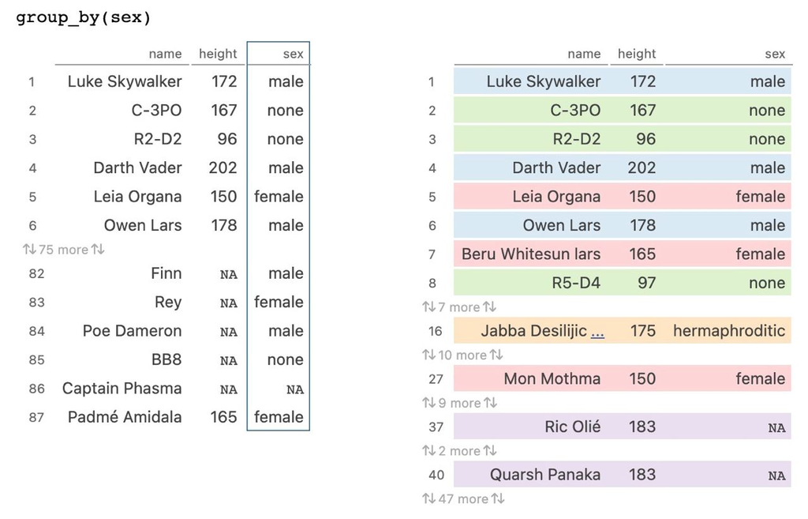

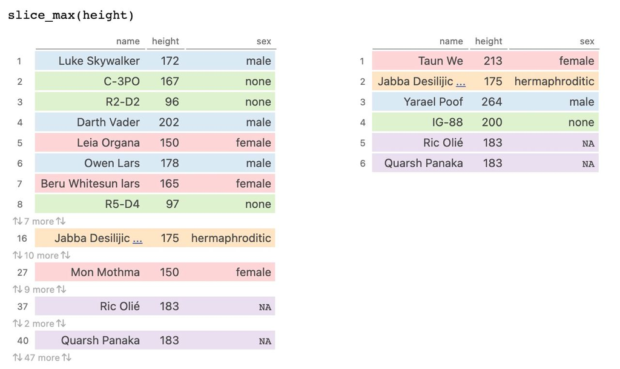

The web https://tidydatatutor.com/ allows to visualize the operations of `{tidyverse}` (doing with the old pipe `%>%`)

## group_by()

```r
data |>
  group(var1, var2) |>
  some_action() |>
  ungroup()
```

```r
starwars |>
  group_by(var1, var2) |>
  some_action() |>
  ungroup()
```

**Important**

You should always remember to **make ungroup** to remove the created group variable.

The “new” version of `{dplyr}` now **allows to include the group variable** in the call to many functions with the argument `by = ...` or `.by = ...`.

```r
starwars |> slice_max(height, by = sex)
```

```
# A tibble: 5 × 6
  name                  height  mass hair_color skin_color       eye_color
  <chr>                  <int> <dbl> <chr>      <chr>            <chr>
1 Yarael Poof              264    NA none       white            yellow
2 IG-88                    200   140 none       metal            red
3 Taun We                  213    NA none       grey             black
4 Jabba Desilijic Tiure    175  1358 <NA>       green-tan, brown orange
5 Gregar Typho             185    85 black      dark             brown
```

## Row-by-row: rowwise()

A very useful option used before an operation is also `rowwise()`: every **operation that comes afterwards will be applied on each row separately**. For example, let’s define a dummy set of grades.

```r
grades <- tibble("maths" = c(7.5, 8, 9.1, 3),
                 "language" = c(8, 6, 6.5, 9.2))
```

If we apply the average directly the value will be identical since it has done the global average, but we would like to get an **average per record**. For that we will use `rowwise()`.

```r
grades |>
  rowwise() |>
  mutate(ave_grades = mean(c(maths, language)))
```

```
# A tibble: 4 × 3
# Rowwise:
  maths language ave_grades
  <dbl>    <dbl>      <dbl>
1   7.5      8         7.75
2   8        6         7
3   9.1      6.5       7.8
4   3        9.2       6.1
```

## Summary: summarise()

```r
data |> simple_summary()
```

```r
starwars |> summarise()
```

Finally we have `summarise()`, which will allow us to get statistical summaries. For example, let’s **calculate the average of the heights**.

```r
starwars |>
  drop_na(height) |>
  summarise(ave_height = mean(height))
```

```
# A tibble: 1 × 1
  ave_height
       <dbl>
1       175.
```

**Be careful**

Notice that `mutate()` returns **as many rows as original records**, while with `summarise()` it calculates a **new summary dataset**, only including what is indicated.

## Summary: summarise()

```r
data |> simple_summary()
```

```r
starwars |> summarise()
```

If we also **combine this with the grouping** of `group_by()` or `.by = ...`, in a few lines of code you can get **disaggregated statistics**.

```r
starwars |>
  drop_na(sex, height, mass) |>
  summarise(ave_height = mean(height),
            ave_mass = mean(mass),
            .by = sex)
```

```
# A tibble: 4 × 3
  sex            ave_height ave_mass
  <chr>               <dbl>    <dbl>
1 male                 178.     80.2
2 none                 140      69.8
3 female               172.     54.7
4 hermaphroditic       175    1358
```

## Summary: reframe()

```r
data |> complex_summary()
```

```r
starwars |> reframe()
```

In the new `{dplyr}` they have included `reframe()` to avoid `summarise()` problems when **we return more than one value per variable** in more complex summaries.

```r
starwars |>
  drop_na(mass) |>
  summarise(quantile(mass))
```

```
# A tibble: 5 × 1
  `quantile(mass)`
             <dbl>
1             15
2             55.6
3             79
4             84.5
5           1358
```

```r
starwars |>
  drop_na(mass) |>
  reframe(quantile(mass))
```

```
# A tibble: 5 × 1
  `quantile(mass)`
             <dbl>
1             15
2             55.6
3             79
4             84.5
5           1358
```

## across()

One trick is to **make use of selectors** `across()` and `where()`. The former allows us to **act on several columns by name** (with `mutate()` or `summarise()`).

```r
starwars |> summarise(ave = across(height:mass, mean, na.rm = TRUE), .by = sex)
```

```
# A tibble: 5 × 2
  sex            ave$height  $mass
  <chr>               <dbl>  <dbl>
1 male                 179.   80.2
2 none                 131.   69.8
3 female               172.   54.7
4 hermaphroditic       175  1358
5 <NA>                 175    81
```

The second, `where()`, allows us to do the same but **selecting by type**.

```r
starwars |>
  summarise(across(where(is.numeric), mean, na.rm = TRUE), .by = c(sex, gender))
```

```
# A tibble: 6 × 5
  sex            gender    height   mass birth_year
  <chr>          <chr>      <dbl>  <dbl>      <dbl>
1 male           masculine   179.   80.2       84.8
2 none           masculine   140    69.8       53.3
3 female         feminine    172.   54.7       47.2
4 hermaphroditic masculine   175  1358        600
5 <NA>           <NA>        175    81        NaN
6 none           feminine     96   NaN        NaN
```

## 💻 It’s your turn

**Try to perform the following exercises without looking at the solutions**

- **Exercise 1**
- **Exercise 2**
- **Exercise 3**
- **Exercise 4**
- **Exercise 5**

📝 Calculate how many characters there are of each species, ordered from most to least frequent.

```r
starwars |> count(species, sort = TRUE)
```

📝 After eliminating missing variables for weight and height, add a new variable to calculate the BMI of each character, and determine the average BMI of our characters disaggregated by gender.

```r
starwars |>
  drop_na(mass, height) |>
  mutate(BMI = mass / ((height/100)^2)) |>
  summarise(ave_BMI = mean(BMI), .by = sex)
```

📝 Obtain the youngest character for each gender.

```r
starwars |> # reminder that birth_year is in fact the age
  slice_min(birth_year, by = sex)
```

📝 Get the age of the youngest and oldest character of each sex.

```r
starwars |>
  drop_na(birth_year) |>
  summarise(min(birth_year), max(birth_year), .by = sex)
```

📝 Determine the number of characters in each decade (take a look at `round()`, first without disaggregating and then disaggregated by sex.

```r
starwars |>
  count(birth_decade = round(birth_year, -1))
```

## 🐣 Case study I: billboard

We are going to do a **summary of what we learned** in `{tidyverse}` with the billboard table of the `{tidyr}` package. The dataset represents something similar to the top 40 (but American version and a top 100 instead of 40): for each artist and song we store the date when it entered the ranking, and the position it occupied in the ranking in each of the weeks (`wk1`, `wk2`, …).

```r
billboard
```

```
# A tibble: 317 × 8
   artist         track               date.entered   wk1   wk2   wk3   wk4   wk5
   <chr>          <chr>               <date>       <dbl> <dbl> <dbl> <dbl> <dbl>
 1 2 Pac          Baby Don't Cry (Ke… 2000-02-26      87    82    72    77    87
 2 2Ge+her        The Hardest Part O… 2000-09-02      91    87    92    NA    NA
 3 3 Doors Down   Kryptonite          2000-04-08      81    70    68    67    66
 4 3 Doors Down   Loser               2000-10-21      76    76    72    69    67
 5 504 Boyz       Wobble Wobble       2000-04-15      57    34    25    17    17
 6 98^0           Give Me Just One N… 2000-08-19      51    39    34    26    26
 7 A*Teens        Dancing Queen       2000-07-08      97    97    96    95   100
 8 Aaliyah        I Don't Wanna       2000-01-29      84    62    51    41    38
 9 Aaliyah        Try Again           2000-03-18      59    53    38    28    21
10 Adams, Yolanda Open My Heart       2000-08-26      76    76    74    69    68
# ℹ 307 more rows
```

Try to answer the questions posed in the **workbook `intro-tidyverse`**

## 🐣 Case study II: speechs

```r
library(stringr)
```

The dataset will be `discursos` (speeches, extracted from https://github.com/lirondos/discursos-de-navidad) where are stored the christmas speeches of the heads of state of Spain from 1946 to 2021 (in dictatorship and in democracy)

```r
load(file = "./data/discursos.RData")
```

Try to answer the questions posed in the **workbook `intro-tidyverse`**

## Import/export

So far we have only used data already loaded in packages but many times **we will need to import data externally**. One of the main **strengths** of `R` is that we can import data very easily in different formats:

- **R native formats**: `.rda`, `.RData` and `.rds` formats.
- **Rectangular (tabular) data**: `.csv` and `.tsv` formats
- **Untabulated data**: `.txt` format.
- **Data in excel**: `.xls` and `.xlsx` formats
- **Data from SAS/Stata/SPSS**: `.sas7bdat`, `.sav` and `.dat` formats
- **Data from Google Drive**
- **Data from API’s**: aemet, catastro, twitter, spotify, etc.

## R native formats

The **simplest** files to import into `R` (and which usually take up less disk space) are its own **native extensions**: files in `.RData`, `.rda` and `.rds` formats. To load the former we simply need to **use the native** function `load()` by providing it the file path.

- `RData` file: we are going to import the file `world_bank_pop.RData`, which includes the dataset `world_bank_pop`

```r
load("./data/world_bank_pop.RData")
world_bank_pop
```

```
# A tibble: 1,064 × 20
   country indicator      `2000`  `2001`  `2002`  `2003`  `2004`  `2005`  `2006`
   <chr>   <chr>           <dbl>   <dbl>   <dbl>   <dbl>   <dbl>   <dbl>   <dbl>
 1 ABW     SP.URB.TOTL    4.16e4 4.20e+4 4.22e+4 4.23e+4 4.23e+4 4.24e+4 4.26e+4
 2 ABW     SP.URB.GROW    1.66e0 9.56e-1 4.01e-1 1.97e-1 9.46e-2 1.94e-1 3.67e-1
 3 ABW     SP.POP.TOTL    8.91e4 9.07e+4 9.18e+4 9.27e+4 9.35e+4 9.45e+4 9.56e+4
 4 ABW     SP.POP.GROW    2.54e0 1.77e+0 1.19e+0 9.97e-1 9.01e-1 1.00e+0 1.18e+0
 5 AFE     SP.URB.TOTL    1.16e8 1.20e+8 1.24e+8 1.29e+8 1.34e+8 1.39e+8 1.44e+8
 6 AFE     SP.URB.GROW    3.60e0 3.66e+0 3.72e+0 3.71e+0 3.74e+0 3.81e+0 3.81e+0
 7 AFE     SP.POP.TOTL    4.02e8 4.12e+8 4.23e+8 4.34e+8 4.45e+8 4.57e+8 4.70e+8
 8 AFE     SP.POP.GROW    2.58e0 2.59e+0 2.61e+0 2.62e+0 2.64e+0 2.67e+0 2.70e+0
 9 AFG     SP.URB.TOTL    4.31e6 4.36e+6 4.67e+6 5.06e+6 5.30e+6 5.54e+6 5.83e+6
10 AFG     SP.URB.GROW    1.86e0 1.15e+0 6.86e+0 7.95e+0 4.59e+0 4.47e+0 5.03e+0
# ℹ 1,054 more rows
# ℹ 11 more variables: `2007` <dbl>, `2008` <dbl>, `2009` <dbl>, `2010` <dbl>,
#   `2011` <dbl>, `2012` <dbl>, `2013` <dbl>, `2014` <dbl>, `2015` <dbl>,
#   `2016` <dbl>, `2017` <dbl>
```

## R native formats

- `.rda` file: we will import the airquality dataset from `airquality.rda`

```r
load("./data/airquality.rda")
airquality |> as_tibble()
```

```
# A tibble: 153 × 6
   Ozone Solar.R  Wind  Temp Month   Day
   <int>   <int> <dbl> <int> <int> <int>
 1    41     190   7.4    67     5     1
 2    36     118   8      72     5     2
 3    12     149  12.6    74     5     3
 4    18     313  11.5    62     5     4
 5    NA      NA  14.3    56     5     5
 6    28      NA  14.9    66     5     6
 7    23     299   8.6    65     5     7
 8    19      99  13.8    59     5     8
 9     8      19  20.1    61     5     9
10    NA     194   8.6    69     5    10
# ℹ 143 more rows
```

## R native formats

Note that files loaded with `load()` are **automatically loaded into the environment** (with the originally saved name), and not only datasets can be loaded: `load()` allows us to load multiple objetcs (not only a tabular data)

Native `.rda` and `.RData` files are a properly way to save your environment.

```r
load(file = "./data/multiple_objects.rda")
```

## R native formats

- `.rds` files: for this type we must use `readRDS()`, and we need to incorporate a **argument `file`** with the path. In this case we are going to import **lung cancer data** from the North Central Cancer Treatment Group. Note that now **.rds import files are a unique database**

```r
lung_cancer <-
  readRDS(file = "./data/NCCTG_lung_cancer.rds") |>
  as_tibble()
```

**Important**

The **paths** must always be **without spaces, ñ, or accents**.

## Tabular data: readr

The `{readr}` package within the `{tidyverse}` environment contains several useful functions for **loading rectangular data (without formatting)**.

- `read_csv()`: `.csv` files whose **separator is comma**
- `read_csv2()`: **semicolon**
- `read_tsv()`: **tabulator**.
- `read_table()`: **space**.
- `read_delim()`: generic function for **character delimited files**.

[figure not shown]

All of them need as **argument the file path** plus **other optional** (skip header or not, decimals, etc). See more at https://readr.tidyverse.org/

## Tabular data (.csv, .tsv)

The main advantage of `{readr}` is that it **automates formatting** to go from a flat (unformatted) file to a tibble (in rows and columns, with formatting).

- File `.csv`: with `read_csv()` we will load **comma separated** files, passing as **argument the path** in `file = ...`. Let’s import the `chickens.csv` dataset (about cartoon chickens, why not). If you look at the output it gives us the type of variables.

```r
library(readr)
chickens <- read_csv(file = "./data/chickens.csv")
chickens
```

```
# A tibble: 5 × 4
  chicken                 sex     eggs_laid motto
  <chr>                   <chr>       <dbl> <chr>
1 Foghorn Leghorn         rooster         0 That's a joke, ah say, that's a jok…
2 Chicken Little          hen             3 The sky is falling!
3 Ginger                  hen            12 Listen. We'll either die free chick…
4 Camilla the Chicken     hen             7 Bawk, buck, ba-gawk.
5 Ernie The Giant Chicken rooster         0 Put Captain Solo in the cargo hold.
```

## Tabular data (.csv, .tsv)

The **variable format** will normally be done **automatically** by `read_csv()`, and we can query it with `spec()`.

```r
spec(chickens)
```

## Tabular data (.csv, .tsv)

Although it usually does it well automatically we can **specify the format explicitly** in `col_types = list()` (in list format, with `col_xxx()` for each type of variable, for example `eggs_laid` will be imported as character).

```r
chickens <-
  read_csv(file = "./data/chickens.csv",
           col_types = list(col_character(), col_character(),
                            col_character(), col_character()))
chickens
```

```
# A tibble: 5 × 4
  chicken                 sex     eggs_laid motto
  <chr>                   <chr>   <chr>     <chr>
1 Foghorn Leghorn         rooster 0         That's a joke, ah say, that's a jok…
2 Chicken Little          hen     3         The sky is falling!
3 Ginger                  hen     12        Listen. We'll either die free chick…
4 Camilla the Chicken     hen     7         Bawk, buck, ba-gawk.
5 Ernie The Giant Chicken rooster 0         Put Captain Solo in the cargo hold.
```

## Tabular data (.csv, .tsv)

We can even indicate that **variables we want to select** (without occupying memory), by indicating it in `col_select = ...` (in list format, with `col_select = ...`).

```r
chickens <-
  read_csv(file = "./data/chickens.csv",
           col_select = c(chicken, sex, eggs_laid))
chickens
```

```
# A tibble: 5 × 3
  chicken                 sex     eggs_laid
  <chr>                   <chr>       <dbl>
1 Foghorn Leghorn         rooster         0
2 Chicken Little          hen             3
3 Ginger                  hen            12
4 Camilla the Chicken     hen             7
5 Ernie The Giant Chicken rooster         0
```

## Untabulated data (.txt)

What happens when the **separator is not correct**?

If we use `read_csv()` it expects the separator between columns to be a comma but, as you can see with the following `.txt`, it interprets everything as a single column: **has no comma and does not know where to separate**

```r
datos_txt <- read_csv(file = "./data/massey-rating.txt")
dim(datos_txt)
```

```
[1] 10  1
```

```r
as_tibble(datos_txt)
```

```
# A tibble: 10 × 1
   `UCC PAY LAZ KPK  RT   COF BIH DII ENG ACU Rank Team            Conf`
   <chr>
 1 1   1   1   1   1     1   1   1   1   1    1 Ohio St          B10
 2 2   2   2   2   2     2   2   2   4   2    2 Oregon           P12
 3 3   4   3   4   3     4   3   4   2   3    3 Alabama          SEC
 4 4   3   4   3   4     3   5   3   3   4    4 TCU              B12
 5 6   6   6   5   5     7   6   5   6  11    5 Michigan St      B10
 6 7   7   7   6   7     6  11   8   7   8    6 Georgia          SEC
 7 5   5   5   7   6     8   4   6   5   5    7 Florida St       ACC
 8 8   8   9   9  10     5   7   7  10   7    8 Baylor           B12
 9 9  11   8  13  11    11  12   9  14   9    9 Georgia Tech     ACC
10 13  10  13  11   8     9  10  11   9  10   10 Mississippi      SEC
```

## Untabulated data (.txt)

To do this we have.

- `read_csv2()` when the **separator is semicolon**, `read_tsv()` when the **is a tab** and `read_table()` when the **is a space**.
- `read_delim()` in general.

```r
datos_txt <- read_table(file = "./data/massey-rating.txt")
as_tibble(datos_txt)
```

```
# A tibble: 10 × 13
     UCC   PAY   LAZ   KPK    RT   COF   BIH   DII   ENG   ACU  Rank Team  Conf
   <dbl> <dbl> <dbl> <dbl> <dbl> <dbl> <dbl> <dbl> <dbl> <dbl> <dbl> <chr> <chr>
 1     1     1     1     1     1     1     1     1     1     1     1 Ohio  St
 2     2     2     2     2     2     2     2     2     4     2     2 Oreg… P12
 3     3     4     3     4     3     4     3     4     2     3     3 Alab… SEC
 4     4     3     4     3     4     3     5     3     3     4     4 TCU   B12
 5     6     6     6     5     5     7     6     5     6    11     5 Mich… St
 6     7     7     7     6     7     6    11     8     7     8     6 Geor… SEC
 7     5     5     5     7     6     8     4     6     5     5     7 Flor… St
 8     8     8     9     9    10     5     7     7    10     7     8 Bayl… B12
 9     9    11     8    13    11    11    12     9    14     9     9 Geor… Tech
10    13    10    13    11     8     9    10    11     9    10    10 Miss… SEC
```

## Excel data (.xls, .xlsx)

Another key import package will be the `{readxl}` package for **importing data from Excel**. Three functions will be key:

- `read_xls()` specific to `.xls`, `read_xlsx()` specific to `.xlsx`.
- `read_excel()`: for both `.xls` and `.xlsx`.

We are going to import `deaths.xlsx` with celebrity death records.

```r
library(readxl)
deaths <- read_xlsx(path = "./data/deaths.xlsx")
deaths
```

```
# A tibble: 18 × 6
   `Lots of people`             ...2                     ...3  ...4  ...5  ...6
   <chr>                        <chr>                    <chr> <chr> <chr> <chr>
 1 simply cannot resist writing <NA>                     <NA>  <NA>  <NA>  some…
 2 at                           the                      top   <NA>  of    thei…
 3 or                           merging                  <NA>  <NA>  <NA>  cells
 4 Name                         Profession               Age   Has … Date… Date…
 5 David Bowie                  musician                 69    TRUE  17175 42379
 6 Carrie Fisher                actor                    60    TRUE  20749 42731
 7 Chuck Berry                  musician                 90    TRUE  9788  42812
 8 Bill Paxton                  actor                    61    TRUE  20226 42791
 9 Prince                       musician                 57    TRUE  21343 42481
10 Alan Rickman                 actor                    69    FALSE 16854 42383
11 Florence Henderson           actor                    82    TRUE  12464 42698
12 Harper Lee                   author                   89    FALSE 9615  42419
13 Zsa Zsa Gábor                actor                    99    TRUE  6247  42722
14 George Michael               musician                 53    FALSE 23187 42729
15 Some                         <NA>                     <NA>  <NA>  <NA>  <NA>
16 <NA>                         also like to write stuff <NA>  <NA>  <NA>  <NA>
17 <NA>                         <NA>                     at t… bott… <NA>  <NA>
18 <NA>                         <NA>                     <NA>  <NA>  <NA>  too!
```

## Excel data (.xls, .xlsx)

```r
deaths |> slice(1:6)
```

```
# A tibble: 6 × 6
  `Lots of people`             ...2       ...3  ...4     ...5          ...6
  <chr>                        <chr>      <chr> <chr>    <chr>         <chr>
1 simply cannot resist writing <NA>       <NA>  <NA>     <NA>          some not…
2 at                           the        top   <NA>     of            their sp…
3 or                           merging    <NA>  <NA>     <NA>          cells
4 Name                         Profession Age   Has kids Date of birth Date of …
5 David Bowie                  musician   69    TRUE     17175         42379
6 Carrie Fisher                actor      60    TRUE     20749         42731
```

One thing that is **very common misfortune** is that there is some kind of comment or text at the beginning of the file, having to **skip those rows**.

## Excel data (.xls, .xlsx)

We can **skip these rows** directly in the load with `skip = ...` (indicating the number of rows to skip).

```r
deaths <- read_xlsx(path = "./data/deaths.xlsx", skip = 4)
deaths
```

```
# A tibble: 14 × 6
   Name          Profession Age   `Has kids` `Date of birth`     `Date of death`
   <chr>         <chr>      <chr> <chr>      <dttm>              <chr>
 1 David Bowie   musician   69    TRUE       1947-01-08 00:00:00 42379
 2 Carrie Fisher actor      60    TRUE       1956-10-21 00:00:00 42731
 3 Chuck Berry   musician   90    TRUE       1926-10-18 00:00:00 42812
 4 Bill Paxton   actor      61    TRUE       1955-05-17 00:00:00 42791
 5 Prince        musician   57    TRUE       1958-06-07 00:00:00 42481
 6 Alan Rickman  actor      69    FALSE      1946-02-21 00:00:00 42383
 7 Florence Hen… actor      82    TRUE       1934-02-14 00:00:00 42698
 8 Harper Lee    author     89    FALSE      1926-04-28 00:00:00 42419
 9 Zsa Zsa Gábor actor      99    TRUE       1917-02-06 00:00:00 42722
10 George Micha… musician   53    FALSE      1963-06-25 00:00:00 42729
11 Some          <NA>       <NA>  <NA>       NA                  <NA>
12 <NA>          also like… <NA>  <NA>       NA                  <NA>
13 <NA>          <NA>       at t… bottom,    NA                  <NA>
14 <NA>          <NA>       <NA>  <NA>       NA                  too!
```

## Excel data (.xls, .xlsx)

In addition with `col_names = ...` we can already rename the columns in the import (if **provide names assumes 1st line already as a data**)

```r
deaths <-
  read_xlsx(path = "./data/deaths.xlsx", skip = 5,
            col_names = c("name", "profession", "age", "kids", "birth", "death"))
deaths
```

```
# A tibble: 14 × 6
   name               profession           age   kids  birth               death
   <chr>              <chr>                <chr> <chr> <dttm>              <chr>
 1 David Bowie        musician             69    TRUE  1947-01-08 00:00:00 42379
 2 Carrie Fisher      actor                60    TRUE  1956-10-21 00:00:00 42731
 3 Chuck Berry        musician             90    TRUE  1926-10-18 00:00:00 42812
 4 Bill Paxton        actor                61    TRUE  1955-05-17 00:00:00 42791
 5 Prince             musician             57    TRUE  1958-06-07 00:00:00 42481
 6 Alan Rickman       actor                69    FALSE 1946-02-21 00:00:00 42383
 7 Florence Henderson actor                82    TRUE  1934-02-14 00:00:00 42698
 8 Harper Lee         author               89    FALSE 1926-04-28 00:00:00 42419
 9 Zsa Zsa Gábor      actor                99    TRUE  1917-02-06 00:00:00 42722
10 George Michael     musician             53    FALSE 1963-06-25 00:00:00 42729
11 Some               <NA>                 <NA>  <NA>  NA                  <NA>
12 <NA>               also like to write … <NA>  <NA>  NA                  <NA>
13 <NA>               <NA>                 at t… bott… NA                  <NA>
14 <NA>               <NA>                 <NA>  <NA>  NA                  too!
```

## Excel data (.xls, .xlsx)

Sometimes **Excel dates are incorrectly formatted** (surprise): we can use `convertToDate()` from the `{openxlsx}` package to convert it.

```r
library(openxlsx)
deaths$death <- convertToDate(deaths$death)
deaths
```

```
# A tibble: 14 × 6
   name               profession      age   kids  birth               death
   <chr>              <chr>           <chr> <chr> <dttm>              <date>
 1 David Bowie        musician        69    TRUE  1947-01-08 00:00:00 2016-01-10
 2 Carrie Fisher      actor           60    TRUE  1956-10-21 00:00:00 2016-12-27
 3 Chuck Berry        musician        90    TRUE  1926-10-18 00:00:00 2017-03-18
 4 Bill Paxton        actor           61    TRUE  1955-05-17 00:00:00 2017-02-25
 5 Prince             musician        57    TRUE  1958-06-07 00:00:00 2016-04-21
 6 Alan Rickman       actor           69    FALSE 1946-02-21 00:00:00 2016-01-14
 7 Florence Henderson actor           82    TRUE  1934-02-14 00:00:00 2016-11-24
 8 Harper Lee         author          89    FALSE 1926-04-28 00:00:00 2016-02-19
 9 Zsa Zsa Gábor      actor           99    TRUE  1917-02-06 00:00:00 2016-12-18
10 George Michael     musician        53    FALSE 1963-06-25 00:00:00 2016-12-25
11 Some               <NA>            <NA>  <NA>  NA                  NA
12 <NA>               also like to w… <NA>  <NA>  NA                  NA
13 <NA>               <NA>            at t… bott… NA                  NA
14 <NA>               <NA>            <NA>  <NA>  NA                  NA
```

## Excel data (.xls, .xlsx)

We can also **load an Excel with several sheets**: to **indicate the sheet** (either by its name or by its number) we will use the argument `sheet = ...`.

```r
mtcars <- read_xlsx(path = "./data/datasets.xlsx", sheet = "mtcars")
mtcars
```

```
# A tibble: 32 × 11
     mpg   cyl  disp    hp  drat    wt  qsec    vs    am  gear  carb
   <dbl> <dbl> <dbl> <dbl> <dbl> <dbl> <dbl> <dbl> <dbl> <dbl> <dbl>
 1  21       6  160    110  3.9   2.62  16.5     0     1     4     4
 2  21       6  160    110  3.9   2.88  17.0     0     1     4     4
 3  22.8     4  108     93  3.85  2.32  18.6     1     1     4     1
 4  21.4     6  258    110  3.08  3.22  19.4     1     0     3     1
 5  18.7     8  360    175  3.15  3.44  17.0     0     0     3     2
 6  18.1     6  225    105  2.76  3.46  20.2     1     0     3     1
 7  14.3     8  360    245  3.21  3.57  15.8     0     0     3     4
 8  24.4     4  147.    62  3.69  3.19  20       1     0     4     2
 9  22.8     4  141.    95  3.92  3.15  22.9     1     0     4     2
10  19.2     6  168.   123  3.92  3.44  18.3     1     0     4     4
# ℹ 22 more rows
```

## Excel data (.xls, .xlsx)

We can even indicate the **range of cells** to load with `range = ...`.

```r
iris <- read_xlsx(path = "./data/datasets.xlsx", sheet = "iris", range = "C1:E4")
iris
```

```
# A tibble: 3 × 3
  Petal.Length Petal.Width Species
         <dbl>       <dbl> <chr>
1          1.4         0.2 setosa
2          1.4         0.2 setosa
3          1.3         0.2 setosa
```

## Import from SAS/STATA/SPSS

The `{haven}` package within the tidyverse orbit will allow us to **import files from the 3 most important payment software**: SAS, SPSS and Stata.

```r
library(haven)

# SAS
iris_sas <- read_sas(data_file = "./data/iris.sas7bdat")

# SPSS
iris_spss <- read_sav(file = "./data/iris.sav")

# Stata
iris_stata <- read_dta(file = "./data/iris.dta")
```

## Export

In the same way that we can import we can also **export**

- exported in `.RData` (recommended option for variables stored in `R`). Remember that this extension **can only be used in `R`**. To do so, just use `save(object, file = path)`.

```r
table <- tibble("a" = 1:4, "b" = 1:4)
save(table, file = "./data/table.RData")
rm(table) # eliminar
load("./data/table.RData")
table
```

```
# A tibble: 4 × 2
      a     b
  <int> <int>
1     1     1
2     2     2
3     3     3
4     4     4
```

## Export

In the same way that we can import we can also **export**

- exported in `.RData` multiple objects

```r
table <- tibble("a" = 1:4, "b" = 1:4)
a <- 1
b <- c("javi", "sandra")
save(table, a, b, file = "./data/mult_obj.RData")
rm(list = c("a", "b", "table"))
load("./data/mult_obj.RData")
table
```

```
# A tibble: 4 × 2
      a     b
  <int> <int>
1     1     1
2     2     2
3     3     3
4     4     4
```

## Export

In the same way that we can import we can also **export**

- exported in `.csv`. To do this we simply use `write_csv(object, file = path)`.

```r
write_csv(table, file = "./data/table.csv")
read_csv(file = "./data/table.csv")
```

```
# A tibble: 4 × 2
      a     b
  <dbl> <dbl>
1     1     1
2     2     2
3     3     3
4     4     4
```

## Import from website

One of the main advantages of `R` is that we can make use of all the previous functions of **import but directly from a web**, without the need to perform the manual download: instead of passing it the local path we will indicate the **link**. For example, we are going to download the covid data from ISCIII (https://cnecovid.isciii.es/covid19/#documentaci%C3%B3n-y-datos)

```r
covid_data <-
  read_csv(file = "https://cnecovid.isciii.es/covid19/resources/casos_hosp_uci_def_sexo_edad_provres.csv")
covid_data
```

```
# A tibble: 500 × 8
   provincia_iso sexo  grupo_edad fecha      num_casos num_hosp num_uci num_def
   <chr>         <chr> <chr>      <date>         <dbl>    <dbl>   <dbl>   <dbl>
 1 A             H     0-9        2020-01-01         0        0       0       0
 2 A             H     10-19      2020-01-01         0        0       0       0
 3 A             H     20-29      2020-01-01         0        0       0       0
 4 A             H     30-39      2020-01-01         0        0       0       0
 5 A             H     40-49      2020-01-01         0        0       0       0
 6 A             H     50-59      2020-01-01         0        0       0       0
 7 A             H     60-69      2020-01-01         0        0       0       0
 8 A             H     70-79      2020-01-01         0        0       0       0
 9 A             H     80+        2020-01-01         0        0       0       0
10 A             H     NC         2020-01-01         0        0       0       0
# ℹ 490 more rows
```

## Import from wikipedia

The `{rvest}` package, one of the most useful of `{tidyverse}` allows us to import directly from an `html`. For example, to export wikipedia tables just `read_html()` to import the html, `html_element("table")` to extract the table objects, and `html_table()` to convert the html table to `tibble`.

```r
library(rvest)
wiki_jump <- 'https://en.wikipedia.org/wiki/Men%27s_long_jump_world_record_progression'
wiki_jump |> read_html() |>
  html_element("table") |>
  html_table()
```

```
# A tibble: 24 × 4
   Mark                     Athlete                      Place         Date
   <chr>                    <chr>                        <chr>         <chr>
 1 6.97 m (22 ft 10+1⁄4 in) T. Rodgers (USA)             San Francisco 5 Januar…
 2 6.98 m (22 ft 10+3⁄4 in) Harry Worthington (USA)      Hanover, NH   8 March …
 3 7.11 m (23 ft 3+3⁄4 in)  Aleksander Klumberg (EST)    Tartu         19 Decem…
 4 7.49 m (24 ft 6+3⁄4 in)  William DeHart Hubbard (USA) Urbana        1 March …
 5 7.50 m (24 ft 7+1⁄4 in)  William DeHart Hubbard (USA) New York      20 March…
 6 7.70 m (25 ft 3 in)      Jesse Owens (USA)            New York      24 Febru…
 7 7.71 m (25 ft 3+1⁄2 in)  Eulace Peacock (USA)         New York      23 Febru…
 8 7.82 m (25 ft 7+3⁄4 in)  Jesse Owens (USA)            New York      23 Febru…
 9 7.85 m (25 ft 9 in)      Jesse Owens (USA)            New York      23 Febru…
10 7.86 m (25 ft 9+1⁄4 in)  Irvin Roberson (USA)         New York      20 Febru…
# ℹ 14 more rows
```

## Import from google drive

Another option available (especially if we work with other people working) is to **import from a Google Drive spreadsheet**, making use of `read_sheet()` from the `{googlesheets4}` package.

The first time you will be asked for a tidyverse permission to interact with your drive

```r
library(googlesheets4)
google_sheet <-
  read_sheet("https://docs.google.com/spreadsheets/d/1Uz38nHjl3bmftxDpcXj--DYyPo1I39NHVf-xjeg1_wI/edit?usp=sharing")
google_sheet
```

## Import from API (owid)

Another interesting option is the **data download from an API**: an intermediary between an app or data provider and our `R`. For example, let’s load the `{owidR}` library, which allows us to download data from the web https://ourworldindata.org/. For example, the `owid_covid()` function loads without realizing it more than 400 000 records with more than 60 variables from 238 countries.

```r
library(owidR)
owid_covid() |> as_tibble()
```

## Import from API (aemet)

In many occasions to connect to the API we will first have to **register and obtain a key**, this is the case of the `{climaemet}` package to access **Spanish meteorological data** (https://opendata.aemet.es/centrodedescargas/inicio).

Once we have the API key we register it in our RStudio to be able to use it in the future.

```r
library(climaemet)

# Api key
apikey <- "eyJhbGciOiJIUzI1NiJ9.eyJzdWIiOiJqYXZhbHYwOUB1Y20uZXMiLCJqdGkiOiI4YTU1ODUxMS01MTE3….HEMR77lZy2ASjmOxJa8ppx2J8Za1IViurMX3p1reVBU"

aemet_api_key(apikey, install = TRUE)
```

## Import from API (aemet)

With this package we can do a **search for stations** to know both its postal code and its identifier code within the AEMET network

```r
stations <- aemet_stations()
stations
```

## Import from API (aemet)

For example, to get data from the station of the airport of El Prat, Barcelona, the code to provide is `"0076"`, obtaining **hourly data**

```r
aemet_last_obs("0076")
```

## Importar from API (US census)

One of the most useful tools in recent years is known as `{tidycensus}`: a tool for **facilitating the process of downloading census data** for the United States from `R`.

```r
library(tidycensus)
```

- `get_decennial()`: to access the **census data (US Decennial Census)**, done every 10 years (years 2000, 2010 and 2020).
- `get_acs()`: to access the **annual and quinquennial (5 years) ACS (American Community Survey)** (census != survey)
- `get_estimates()`: to access the **annual population, birth and death estimates** (census != survey)
- `get_pums()`: to access the **microdata (unaggregated data) of the ACS (anonymized at the individual level)**
- `get_flows()`: to access the **migration flow** data.

## Importar from API (US census)

For example, we will download the **census data** (`get_decennial()`) at the state level (`geography = “state”`) for the population (variable `variables = “P001001”`) for the year 2010 (see variables in `tidycensus::load_variables()`).

```r
total_population_10 <-
  get_decennial(geography = "state",
  variables = "P001001",
  year = 2010)
total_population_10
```

```
# A tibble: 52 × 4
   GEOID NAME        variable    value
   <chr> <chr>       <chr>       <dbl>
 1 01    Alabama     P001001   4779736
 2 02    Alaska      P001001    710231
 3 04    Arizona     P001001   6392017
 4 05    Arkansas    P001001   2915918
 5 06    California  P001001  37253956
 6 22    Louisiana   P001001   4533372
 7 21    Kentucky    P001001   4339367
 8 08    Colorado    P001001   5029196
 9 09    Connecticut P001001   3574097
10 10    Delaware    P001001    897934
# ℹ 42 more rows
```

## Import from API

Other options:

- `{chessR}`: data from chess matches. See https://github.com/JaseZiv/chessR
- `{spotifyr}`: data from Spotify. See https://www.rcharlie.com/spotifyr/
- `{gtrendsR}`: data from Google Trends. See https://github.com/PMassicotte/gtrendsR
- `{scholar}`: data from https://github.com/jkeirstead/scholar

# L8: case study in tidyverse

## Q1

> Carga el archivo .sav

```r
library(tidyverse)
library(haven)
datos_spss <- read_sav(file = "./data/SARCOIMAGE1&2_090724 (1).sav")
```

## Q2-Q3

> Determina número de individuos y número de variables

> Necesitamos tener su código de paciente si o si. Determina de la forma que sepas la cantidad de pacientes que tienen código ausente

```r
# rbase
sum(is.na(datos_spss$Código))

# tidyverse
datos_spss |>
  count(is.na(Código))

datos_spss |>
  summarise("n_ausentes" = sum(is.na(Código)))
```

## Q4a

Selecciona solo las variables - Código, Edad, Peso, Talla, IMC, Velocidadmarcha1, Fumador, OBE_IMC - Charlson, SMM_ESPEN, Four_groups, Sarc_F, Fat_Mass_Index - variables relacionadas con sentarse/levantarse (SitStand) - variables relacionadas con sarcopenia (SARCO)

```r
datos4 <-
  datos_spss |>
  select(Código, Edad, Peso, Talla, IMC, Velocidadmarcha1, Fumador, OBE_IMC,
         Charlson, SMM_ESPEN, Four_groups, Sarc_F, Fat_Mass_Index,
         contains("SitStand"), contains("SARCO"))
```

## Q4b

Instala el paquete janitor y aplica janitor::clean_names() a esa tabla. ¿Qué ha hecho?

```r
datos4 <-
  datos_spss |>
  select(Código, Edad, Peso, Talla, IMC, Velocidadmarcha1, Fumador, OBE_IMC,
         Charlson, SMM_ESPEN, Four_groups, Sarc_F, Fat_Mass_Index,
         contains("SitStand"), contains("SARCO")) |>
  janitor::clean_names()
```

## Q4c

Renombra todas las variables seleccionadas del primer item - a inglés para tenerlo todo estandarizado

```r
datos4 <-
  datos_spss |>
  select(Código, Edad, Peso, Talla, IMC, Velocidadmarcha1, Fumador, OBE_IMC,
         Charlson, SMM_ESPEN, Four_groups, Sarc_F, Fat_Mass_Index,
         contains("SitStand"), contains("SARCO")) |>
  janitor::clean_names() |>
  rename(code = codigo, age = edad, mass = peso, height = talla,
         bmi = imc, walk = velocidadmarcha1, smoker = fumador, obe_bmi = obe_imc)
```

## Q4d

La variable Four_groups contiene los 4 grupos de sarco: normal / obeso / sarcopénico / obeso-sarcopénico. Quédate solo con los pacientes de los que conocemos dicha clasificación.

```r
datos4 <-
  datos_spss |>
  select(Código, Edad, Peso, Talla, IMC, Velocidadmarcha1, Fumador, OBE_IMC,
         Charlson, SMM_ESPEN, Four_groups, Sarc_F, Fat_Mass_Index,
         contains("SitStand"), contains("SARCO")) |>
  janitor::clean_names() |>
  rename(code = codigo, age = edad, mass = peso, height = talla,
         bmi = imc, walk = velocidadmarcha1, smoker = fumador, obe_bmi = obe_imc) |>
  drop_na(four_groups)
write_csv(datos4, file = "./datos_ejercicio4.csv")
```

## Q5

¿Qué % de pacientes desconocemos su edad? ¿Y de cuántos desconocemos la puntuación SARC-F del cuestionario de cribado? Tras comprobarlo elimina todos los pacientes que tengan ausente en alguna de las dos.

```r
datos4 |>
  count(is.na(age)) |>
  mutate("porc" = 100*n/sum(n))

datos4 |>
  summarise("porc_age" = 100*mean(is.na(age)),
            "porc_sarcf" = 100*mean(is.na(sarc_f)))
```

```r
datos5 <-
  datos4 |>
  drop_na(age, sarc_f)
```

## Q6

La variable Fat_Mass_Index representa algo parecido al BMI solo que con los kg de grasa (kg de grasa / estatura^2). Con ella crea una nueva variable en el dataset que sean los kilos de grasa y otra que represente su % respecto a su peso.

```r
datos6 <-
  datos5 |> # Fat_Mass_Index = (kg de grasa / estatura^2)
  # kg de grasa = Fat_Mass_Index* estatura^2
  mutate("kg_fat" = fat_mass_index * (height^2),
         "porc_fat" = 100*kg_fat/mass)
```

## Q7

En la tabla original existían las variables OBE_38FAT y OBE_40.9FAT que deberían almacenar un 1/0 en función de si la persona tiene más de un 38% de grasa o un 40.9%, respectivamente. Recategoriza tu la variable manualmente creando obe_38fat y obe_40fat con el % de grasa corporal creado en 6.

```r
datos7 <-
  datos6 |>
  mutate("obe_38fat" = porc_fat > 38,
         "obe_40_9fat" = porc_fat > 40.9)
```

## Q8

Sabiendo que para recategorizar OBE_BMI se ha usado algún corte en BMI, haz uso de count() para “adivinar” que umbral se ha elegido.

```r
datos7 |>
  count(obe_bmi, bmi > 30)
```

## Q9

- SitStand → valor numérico en segundos (tiempo en completar prueba, menos tiempo = mejor) SitStand_DICO → dicotomizado con un umbral general
- SitStand_ESPEN_DICO → dicotomizado con el umbral específico de ESPEN

La diferencia entre SitStand_DICO y SitStand_ESPEN_DICO es simplemente que usan umbrales distintos para clasificar, ¿cómo podríamos comprobar en qué valores de SitStand empiezan a divergir los dos? Detecta los umbrales usados en ambos

```r
datos7 |>
  filter(sit_stand_dico == 1 & sit_stand_espen_dico == 0) |>
  slice_min(sit_stand)
```

```
# A tibble: 1 × 23
   code   age  mass height   bmi  walk smoker obe_bmi charlson smm_espen
  <dbl> <dbl> <dbl>  <dbl> <dbl> <dbl>  <dbl>   <dbl>    <dbl>     <dbl>
1 70170    88  62.4   1.46  29.3 0.913      1       0        6      18.8
# ℹ 13 more variables: four_groups <dbl+lbl>, sarc_f <dbl>,
#   fat_mass_index <dbl>, sit_stand_espen_dico <dbl>, sit_stand_dico <dbl>,
#   sit_stand <dbl>, sarco_prob <dbl>, sarco_confi <dbl>, sarco_severe <dbl>,
#   kg_fat <dbl>, porc_fat <dbl>, obe_38fat <lgl>, obe_40_9fat <lgl>
```

## Q10

Analicemos la relación entre Fat_Mass_Index y BMI: * 10a. Si tuviéses que cuantificar su relación/asociación con un solo número, ¿qué usarías? Incluye eso en lo que estés pesando en una tabla resumen junto con la media yb la mediana de cada una de las variables

## Q10

10b. Repite el proceso pero desagregado por categoría de Four groups

## Q10

10c. Volviendo al caso sin desagregar, ¿cómo saber si esa correlación es suficientemente distinta de 0 para decir que existe una asociación (estadísticamente significativa) entre ambas? Incluye lo que te permite concluirlo en la tabla resumen del 9a.

## Q10

10d. Exporta el resumen obtenido en 9c. a un .csv

## Q11

Analicemos la relación entre fumador y la clasificación en 4 grupos

- 11a. Recodifica la variable fumador (y tras ello retira los NA en la variable) para tener algo binario
  - 0 si nunca fumó (0) o si tiene NA pero fumó menos de 10 cigarros de media al día
  - 1 si fuma (1) o si tiene NA pero fumó igual o más de 10 cigarros de media al día
  - si es ex-fumador (2):
    - 1 si lo hizo más de 20 años o más de 15 cigarros diarios.
    - 0 en caso contrario.
  - NA si tiene NA en Fumador y NA en cigarros de media al día

## Q11

11b. ¿Qué usarías para cuantificar la relación entre fumar/no fumar y la clasificación en 4 grupos?

## Q12

La variable Sarc_F sale de un cribado hecho mediante cuestionario (paciente reporta sus dificultades de manera subjetiva). Puede dar falsos negativos si el paciente no percibe su limitación o la minimiza. Sin embargo SARCO_PROB/CONFI/SEVERE → diagnóstico objetivo basado en mediciones reales (masa muscular, fuerza, función física, etc)

- 12a. Recategoriza Sarc_F tal que >= 4 –> 1 y 0 en otro caso

## Q12

- 12b. ¿Existe relación entre el cribado y SARCO_PROB?

## Q12

- 12c. Si definimos como SARCO_PROB = 1 verdaderos positivos, crea una tabla resumen que incluya:
- pvalor del 11b
- accuracy: del total de todas, qué % está bien clasificado por Sarc_F?)
- sensibilidad: del total de verdaderos positivos, qué % está bien clasificado?
- especificidad: del total de verdaderos negativos, ¿qué % está bien clasificado?

**Javier Álvarez Liébana** • Course at Real Colegio Complutense at Harvard University